# One Line Plot - The Rest

Walter Xie

09/02/2017

```r
library(gg1L)
#getwd()
```

## Box Whiskers plot

Load the example data *model.test*, and display the first 3 rows:

```r
data(model.test)
model.test[1:3,]
```

```
##   model test performance  OS
## 1   GTR 1044    1.144838 Mac
## 2   GTR 1366    1.081676 Mac
## 3   GTR 1510    1.078596 Mac
```

Plot all performance scores for four GTR models, where each box is the statistical summary of the test:

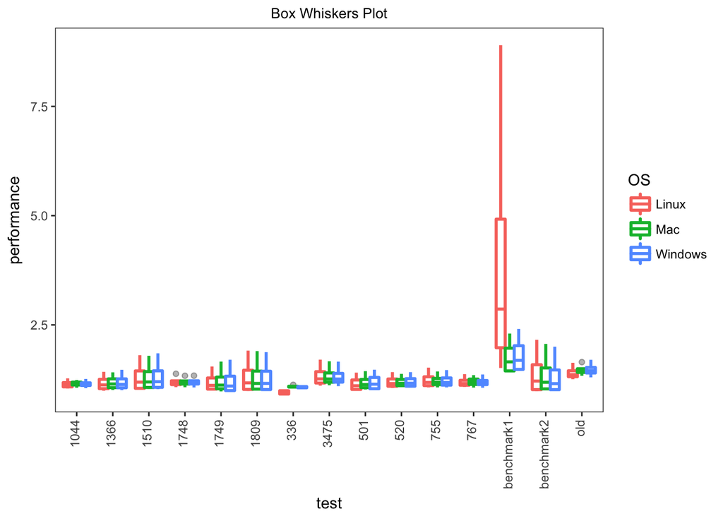

```r
bw1 <- ggBoxWhiskersPlot(model.test, x.id="test", y.id="performance", colour.id="OS", x.text.angle=90, verbose = F)
bw1
```

### Adjust view

Zoom in the plot in y-axis without change the underlying data using `y.lim.cart=c(NA,5)`, where the lower bound is not changed by given “NA”.

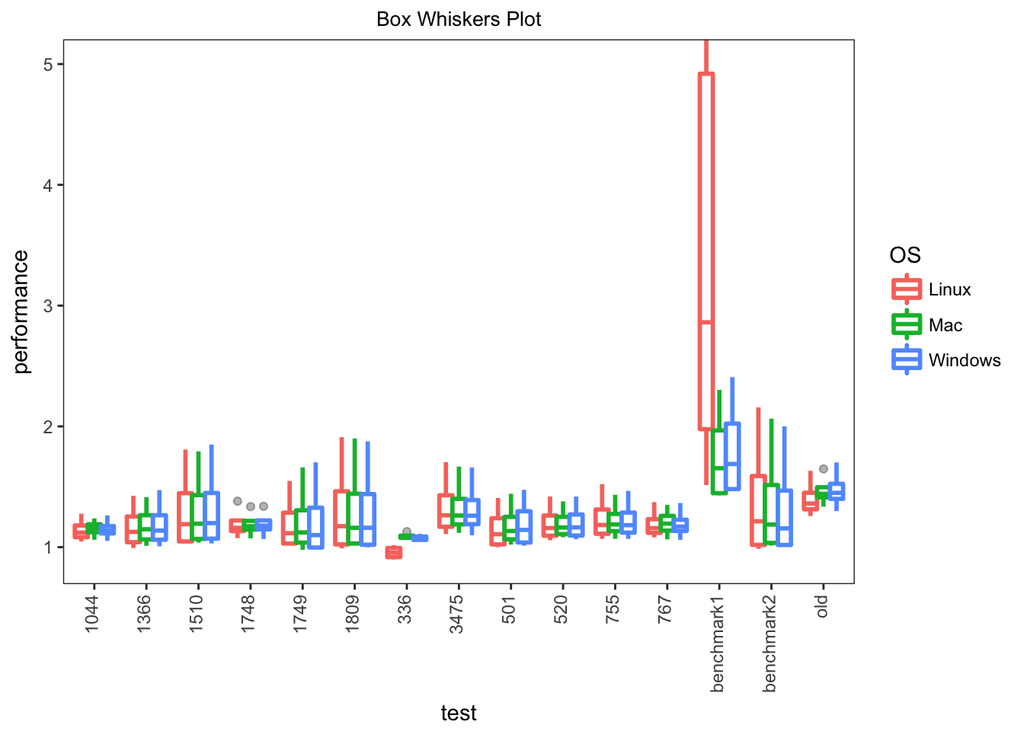

```r
bw2 <- ggBoxWhiskersPlot(model.test, x.id="test", y.id="performance", colour.id="OS", x.text.angle=90, y.lim.cart=c(NA,5), verbose = F)
bw2
```

## Histogram

This plots a 1d distribution by dividing “performance” into bins and counting the number of observations in each bin.

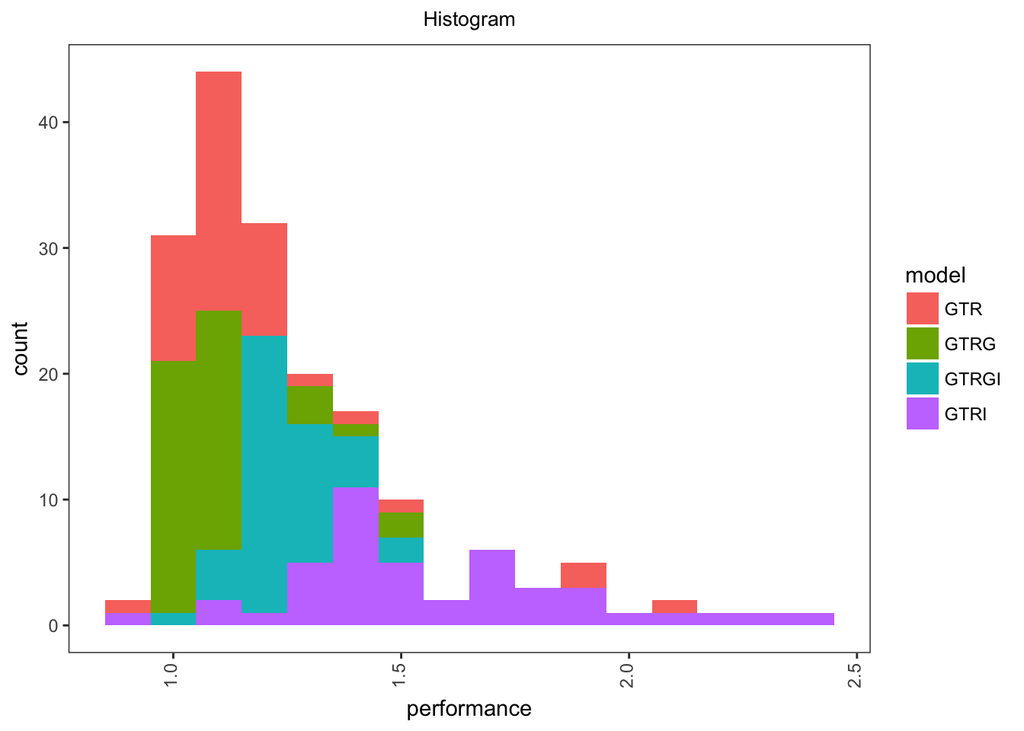

```r
ggHistogram(model.test[model.test$performance<3,], x.id="performance", fill.id="model", binwidth=0.1, x.text.angle=90, verbose=F)
```

## Heatmap

Load the example data *reads.phyla*, where *x* is one of genetic marks, and the numbers are eDNA sequences (reads) identified as the phylum listed in *y*. Remove any column which will be not used, but add “phylum” column for labelling heatmap y-axis. Sort data by row sums and only select the most 20 abundant phyla from 6 genetic markers.

```r
data(reads.phyla)
#reads.phyla[1:2,]
hm.df <- reads.phyla[,-match("TaxaGroup",colnames(reads.phyla))]
# add melt.id
hm.df$phylum <- rownames(hm.df)
# sort data by row sums
hm.df <- hm.df[order(rowSums(hm.df[,1:6]), decreasing=T),]
hm.df <- hm.df[1:20,]
hm.df[1:3,]
```

```
##                 16S 18S trnL  ITS  COI COI-spun         phylum
## Proteobacteria 3862   3 2462   43 1163       75 Proteobacteria
## Basidiomycota     0 850    9 1644   21        1  Basidiomycota
## Ascomycota        2 765   43  971  451       53     Ascomycota
```

Draw a simply heatmap of read frequency in each phylumn, where `melt.id=“phylum”` defines the y-axis label in the heatmap:

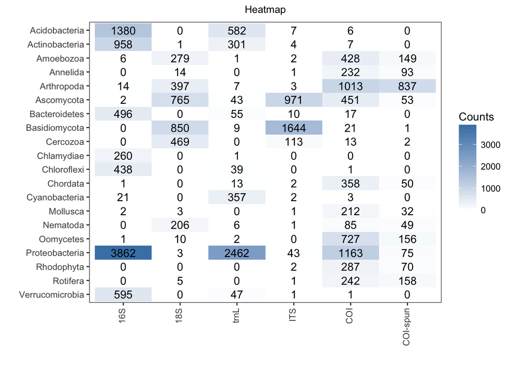

```r
hm1 <- ggHeatmap(hm.df, melt.id="phylum", verbose = F)
hm1
```

Set `log.scale.colour=T` to active logscale colour. Add a line to split the top 5 fom others:

**Note:** the deafult `y.levels=c()` makes y labels sorted by alphabetical order, but if `y.levels=NA`, there is no sorting applied.

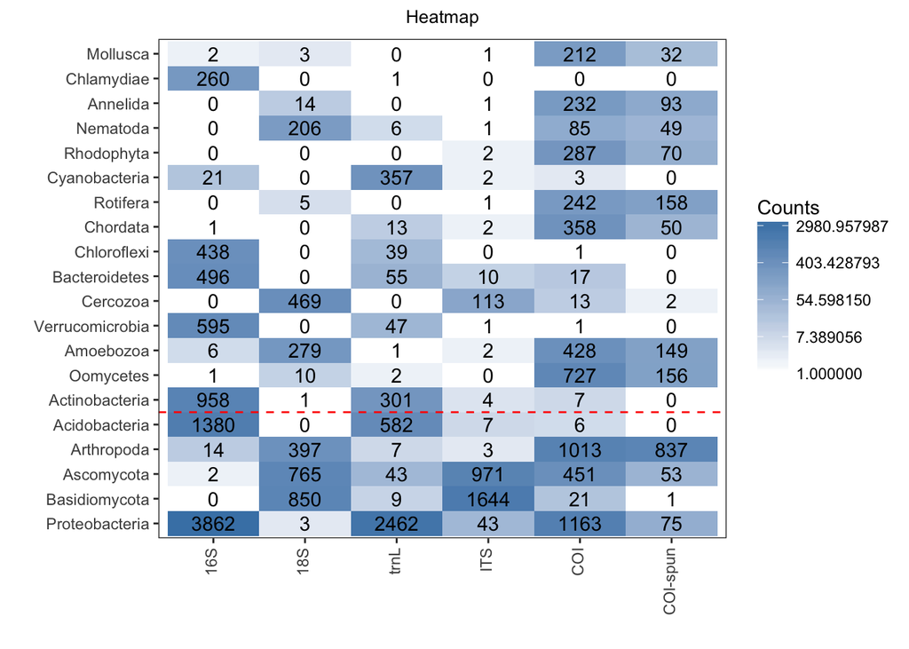

```r
hm2 <- ggHeatmap(hm.df, melt.id="phylum", y.levels=NA, log.scale.colour=T, verbose = F) +
  ggAddLine(linetype=2, yintercept=5.5, colour="red")
hm2
```

The heatmap start to draw the rows from bottom to top as default, you can set `y.levels=rev(rownames(hm.df))` to reverse the order of y labels, and set `add.label=F` to remove the numbers:

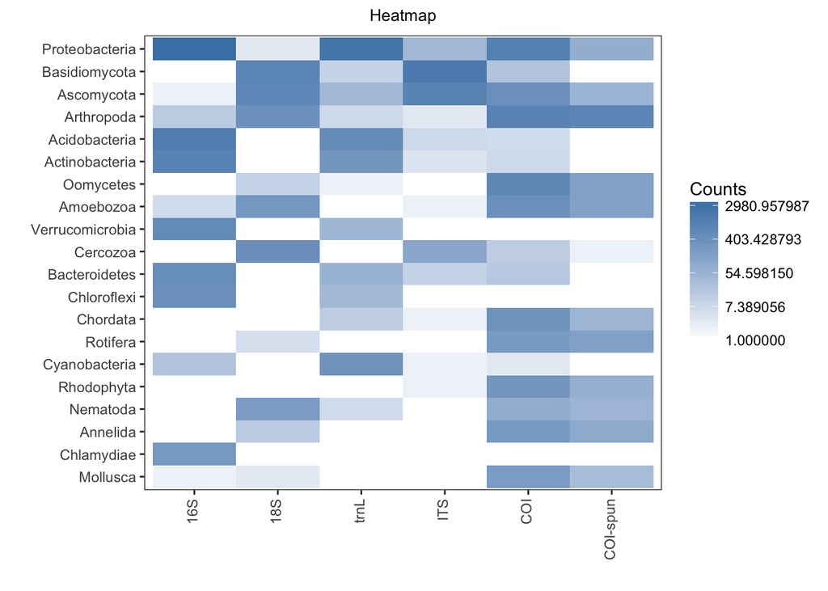

```r
y.rev=rev(rownames(hm.df))
hm3<- ggHeatmap(hm.df, melt.id="phylum", y.levels=y.rev, log.scale.colour=T, add.label=F, verbose = F)
hm3
```

## Utils

`grid_arrange_shared_legend` shares a legend between multiple plots, and returns a *gtable* object:

```r
grid_arrange_shared_legend(bw1, bw2, ncol=2, nrow=1)
```

```
## The grid allocates 2 plots in 2 columns 1 rows.
```

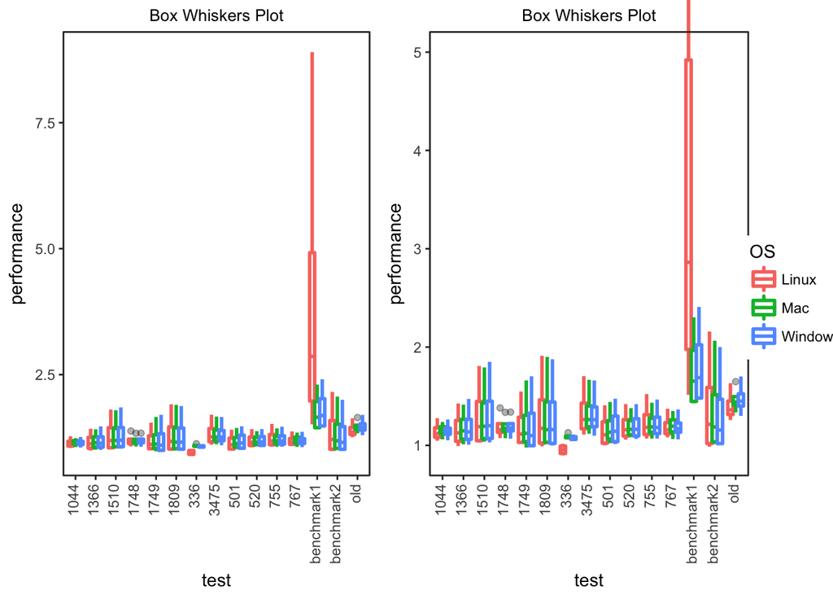

`widths` is a unit vector giving the width of each column in the grid (length(widths) == ncol):

```r
grid_arrange_shared_legend(list(hm1, hm2, hm3), input.list=T, ncol=3, nrow=1, widths=c(1, 0.1, 0.1))
```

```
## The grid allocates 3 plots in 3 columns 1 rows.
```

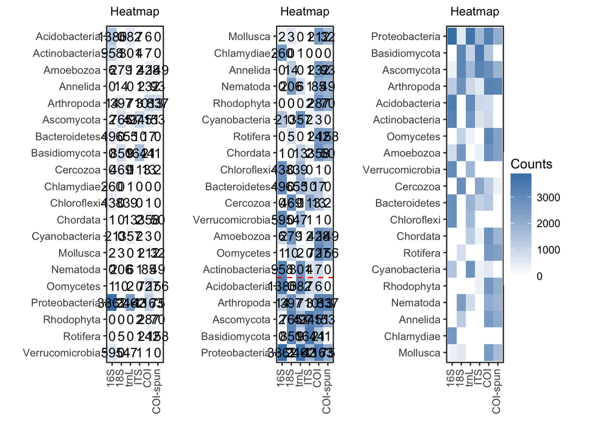

## Some tips

If a function returns a *ggplot* object, then its name starts with “gg”. It needs to use `pdf.ggplot`* to create pdf. It also can be concatenated using ‘+’.

If a function returns a *gtable* object, then its name starts with “gt”. It needs to use `pdf.gtplot` to create pdf, or `plotgt` to plot to console.

All basic charts are designed to return a *ggplot* object for easy to extend, you may need to turn off clipping using  
`unclip.ggplot` if there are overlaps between points/labels and axes.